# macro_graph

## Graph Theory in Macroeconomics

A graph is a network of nodes that are linked by edges. Weighted, directed graphs can describe the flow of commodities, goods, and services in the United States's macroeconomy. A directed graph includes edges that are directional, and a weighted graph includes edges that have associated values. I leverage data from the Bureau of Economic Analysis to visualize inter-industry transactions as weighted, directed graphs. Graph theory is not yet commonly used as an educational tool in traditional macroeconomic courses, however, it may become increasingly important as it allows one to visualize abstract economic concepts. Below is an example of a weighted, directed graph.

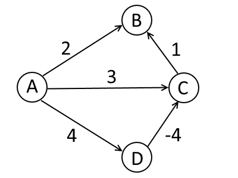

### Data

The Bureau of Economic Analysis uses an input-output system of production accounting. This accounting system consists of two statements: the supply table and use table. The supply table describes the commodities, goods, and services each industry (including imports) produces in the United States. The use table accounts for which of these commodities, goods, and services are used for final consumption, exports, or intermediate use in production. The industries are classified according to the North American Industry Classification System, whereby the economic activity of an establishment is assigned to an industry based on its primary good or service $-$ more information can be found here: (https://bit.ly/2XprDpX). I use the entirety of the data from the supply and use tables in this analysis. Below is a depiction of this accounting system.

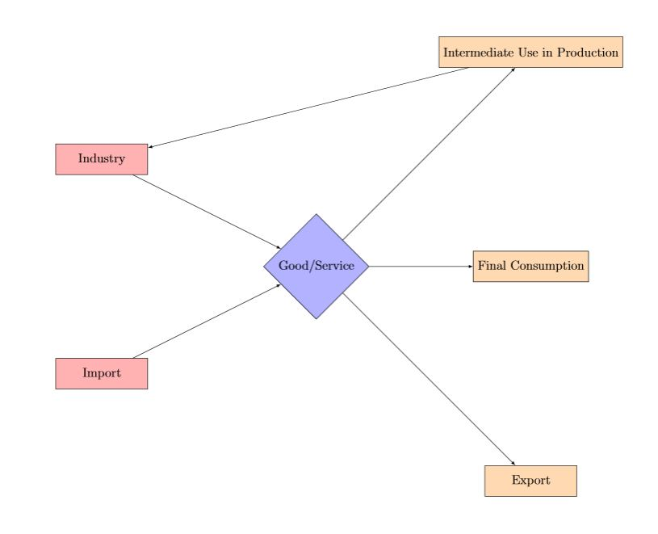

### Graphing

Below is a network graph aggregating the values of the commodities, goods, and services transacted between industries in the United States's macroeconomy in 2018, taken from the supply and use tables. Each node represents an industry, and the edges represent the flow of commodities, goods, and services between them $-$ the width of the edge illustrates the aggregate value of the transactions. Note the coupled nature of production chains, where in many cases the endpoint is Personal Consumption or Exports. We will parse out particularly important production chains later in this analysis. I prepared the data using the Python libraries Pandas and Networkx; I visualized the data using Gephi.

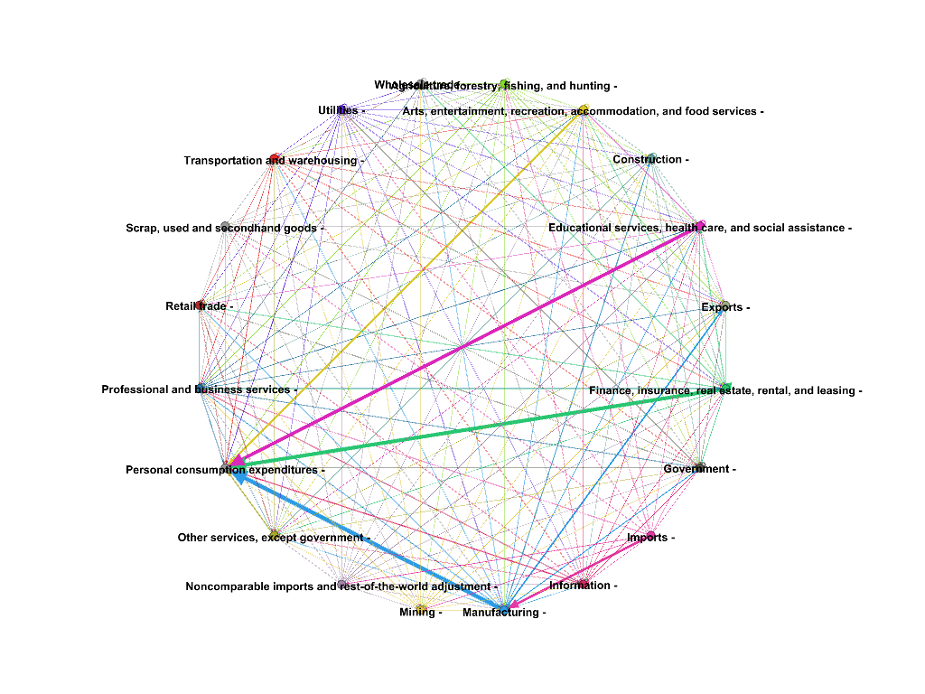

Below is a filtered version of the above graph, where only the aggregate transactions greater than $300 billion are visible.

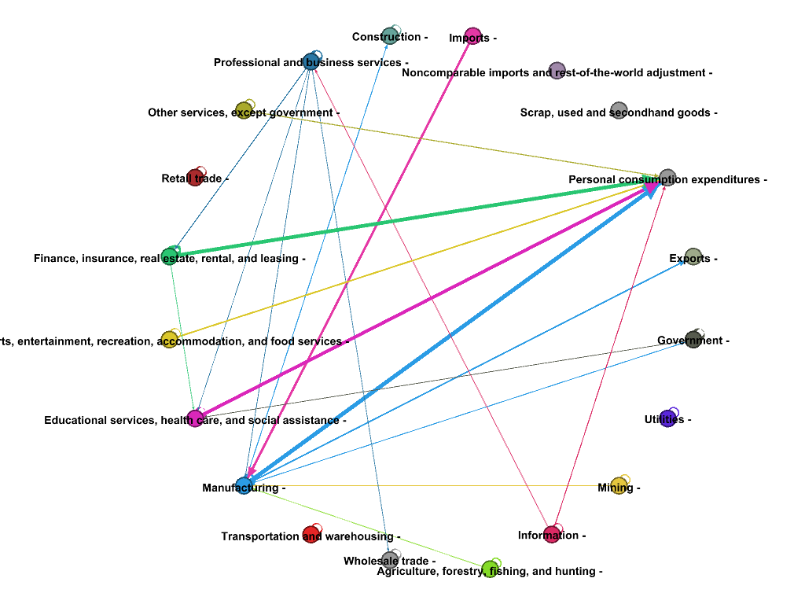

#### Goods

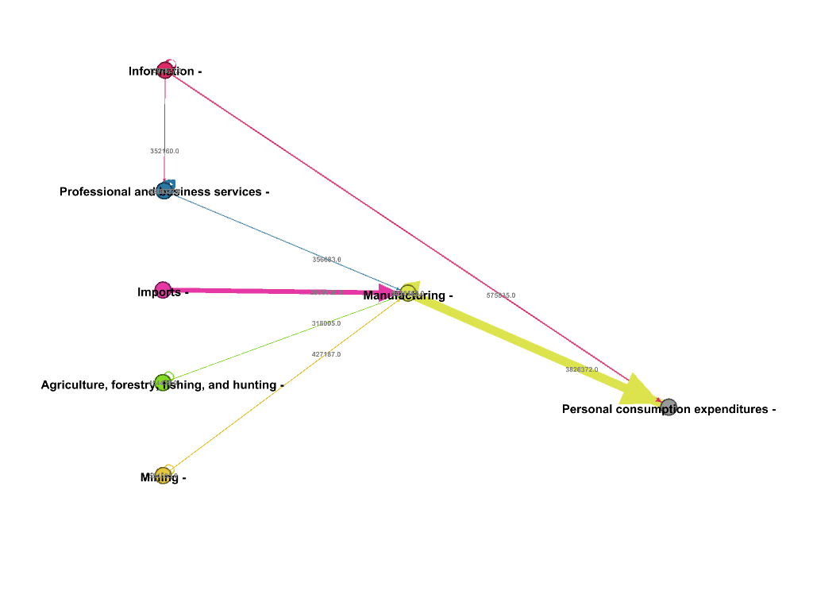

#### Services

Below is the second-highest weighted production chain in the United States's macroeconomy, filtered from the above graph. Personal consumption uses the majority of production from two service industries: Financial services and Education/Health Care/Social services.

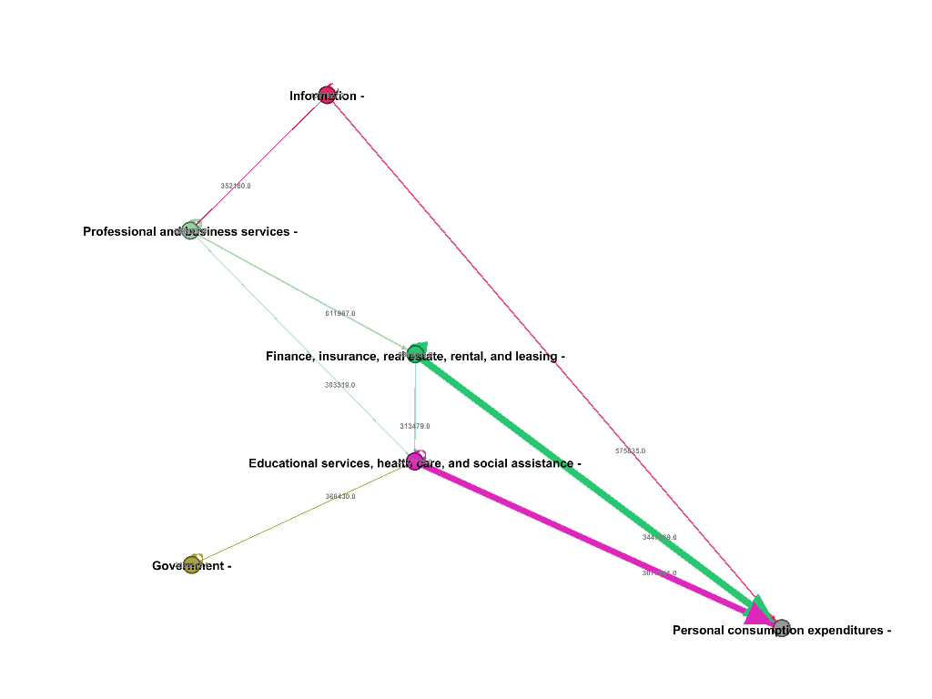

#### Information

The information industry features as a supplier of personal consumption, and it is also an important stage of production within the goods and services industries. This complements existing economic theory, whereby four stages of economic growth are outlined $-$ agricuture-based economies tranformed into manufacturing centers in the early portion of the modern period. In the 20th century, economies became oriented around service provision, and recently, information has become a critical factor of production. Below is a depiction of these stages.

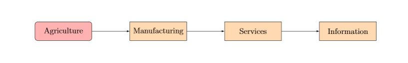

### Concluding Remarks & Further Research

The main purpose of this document is to introduce graph theory as an educational tool to help individuals better understand abstract and complex macroeconomic concepts. This analysis will be extended to include employment by industry. In addition, the Import$\rightarrow$Manufacturing$\rightarrow$Personal Consumption production chain requires further ananlysis from a value add perspective, given the offshore manufacturing trend of recent times. Potentially, a dynamic graph where values are visualized across time may be implemented. Graph theory may also be useful in more advanced modeling scenarios $-$ I plan on implementing a graph-based multi-agent system model to further explore the capabilities of this framework.